# HW1

This author section should be left blank empty for anonymous grading

Due 2024-01-29

## Instruction:

Once you have completed your answer, please submit both the knitted .html file and the .rmd file together.

### Question 1: Write your code in the code chunk and your text answer after the code chunk.

```r
y <- c(1,2,1,3,4,1,1,4,2,1,3,4,3,2,1,3,4,1,2,3,1,1,2,1,1,3,4)
y[y == 1] <- "Freshman"
y[y == 2] <- "Sophomore"
y[y == 3] <- "Junior"
y[y == 4] <- "Senior"
```

Variable `y` is now the following:

Freshman, Sophomore, Freshman, Junior, Senior, Freshman, Freshman, Senior, Sophomore, Freshman, Junior, Senior, Junior, Sophomore, Freshman, Junior, Senior, Freshman, Sophomore, Junior, Freshman, Freshman, Sophomore, Freshman, Freshman, Junior, Senior

### Question 2: Write your code in the code chunk and your text answer after the code chunk.

```r
y <- c(105,69,86,100,82,111,104,110,87,108,87,90,94,113,112,98,80,97,95,111,114,89,95,126,98)

xbar <- mean(y)

n <- length(y)

s <- sd(y)

# We're using a 90% conf. int., so we set alpha to 0.1
alpha <- 0.1

criticalt <- qt(alpha/2, n-1, lower.tail = F)

lower <- xbar - criticalt * s / sqrt(n)
upper <- xbar + criticalt * s / sqrt(n)

# OR Just use a t-test:
  # results <- t.test(y, alternative = "two.sided", mu = 100, conf.level = 0.9)

  # lower <- results$conf.int[1]
  # upper <- results$conf.int[2]
```

**The 90% confidence interval for the average student IQ in the school is [93.9599275, 102.9200725]**

### Question 3: Write your code in the code chunk and your text answer after the code chunk.

```r
# H0: average IQ in the school is 100
# Ha: average IQ in the school is higher than 100

results <- t.test(y, alternative = "greater", mu = 100, conf.level = 0.95)
```

The p-value is 0.7215383, which is more than 0.05. We therefore **fail to reject the null hypothesis**, which means that the population mean for the IQ of students at the school could be less than 100.

### Question 4: Write your code in the code chunk and your text answer after the code chunk.

```r
# Import `expenditure` data set; clean it up a little
expenditure <- read.table("datasets/expenditure.txt", header=T)

expenditure$Region <- factor(expenditure$Region, labels = c("Northeast", "North Central", "South", "West"))

summary(expenditure)
```

```
##     STATE                 Y                X1             X2
##  Length:50          Min.   : 49.00   Min.   :1053   Min.   :334.0
##  Class :character   1st Qu.: 68.25   1st Qu.:1698   1st Qu.:374.2
##  Mode  :character   Median : 81.00   Median :1897   Median :395.0
##                     Mean   : 85.04   Mean   :1912   Mean   :404.7
##                     3rd Qu.:102.00   3rd Qu.:2096   3rd Qu.:419.5
##                     Max.   :142.00   Max.   :2817   Max.   :637.0
##        X3                  Region
##  Min.   :326.0   Northeast    : 9
##  1st Qu.:426.2   North Central:12
##  Median :568.0   South        :16
##  Mean   :561.7   West         :13
##  3rd Qu.:661.2
##  Max.   :899.0
```

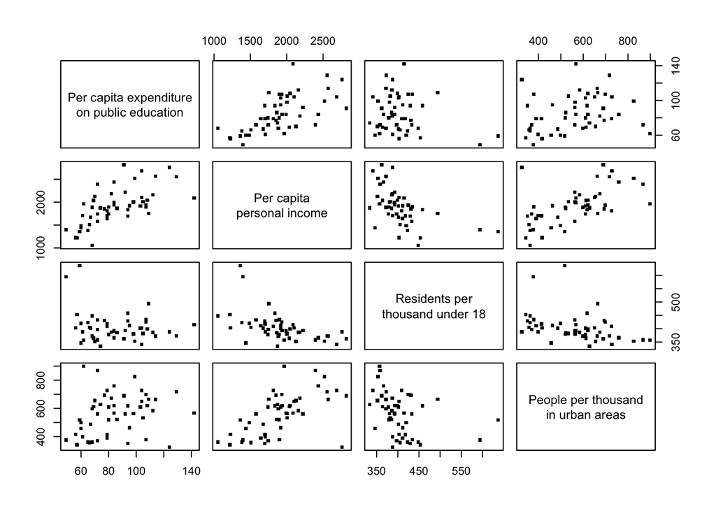

```r
# plot it!
pairs(~ Y + X1 + X2 + X3, data = expenditure,
      labels = c("Per capita expenditure\non public education", "Per capita\npersonal income", "Residents per\nthousand under 18", "People per thousand\nin urban areas"),
      pch = ".",
      cex = 5,
      )
```

```r
yx1 <- cor(expenditure$Y, expenditure$X1)
yx2 <- cor(expenditure$Y, expenditure$X2)
yx3 <- cor(expenditure$Y, expenditure$X3)
x1x2 <- cor(expenditure$X1, expenditure$X2)
x1x3 <- cor(expenditure$X1, expenditure$X3)
x2x3 <- cor(expenditure$X2, expenditure$X3)
```

A scatterplot matrix is the appropriate graph to visualize these relationships.

The correlations are as follows:

|  | Y | X1 | X2 |
| --- | --- | --- | --- |
| **X3** | 0.2481354 | 0.5952504 | -0.3658607 |
| **X2** | -0.2098544 | -0.5293693 |  |
| **X1** | 0.6491296 |  |  |

There is…

- A moderate positive correlation between Y (per capita expenditure on public education) and X1 (per capita personal income)
- A weak positive correlation between Y and X3 (number of people per thousand residing in urban areas)
- A weak negative correlation between Y and X2 (number of residents per thousand under 18 years of age) – but this is approaching no correlation
- A moderate positive correlation between X1 and X3
- A moderate negative relationship between X1 and X2
- A moderate negative relationship between X2 and X3

### Question 5: Write your code in the code chunk and your text answer after the code chunk.

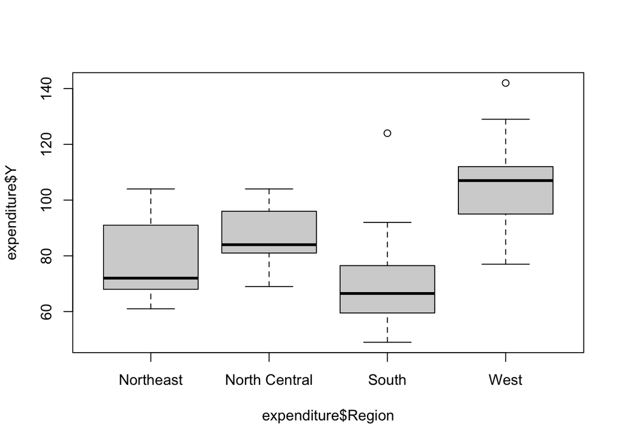

```r
boxplot(expenditure$Y ~ expenditure$Region)
```

```r
results <- t.test(expenditure$Y[expenditure$Region == "West"], alternative = "two.sided", mu = 100, conf.level = 0.95)
```

A side-by-side boxplot is most appropriate to visualize the relationship between Y and Region. On average, the West has the highest per capita expenditure on public education. The confidence interval for the true average per capita expenditure in the West is [95.2805225, 116.7194775].

### Question 6: Write your code in the code chunk and your text answer after the code chunk.

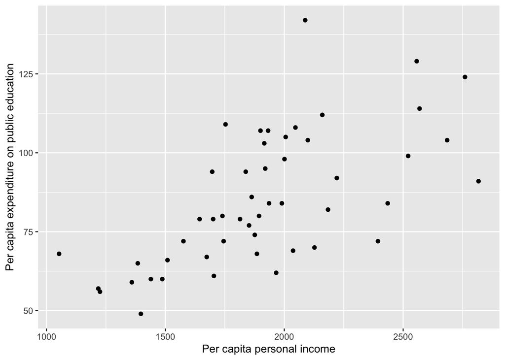

```r
ggplot(expenditure) +
  geom_point(aes(x = X1, y = Y)) +
  xlab("Per capita personal income") +
  ylab("Per capita expenditure on public education")
```

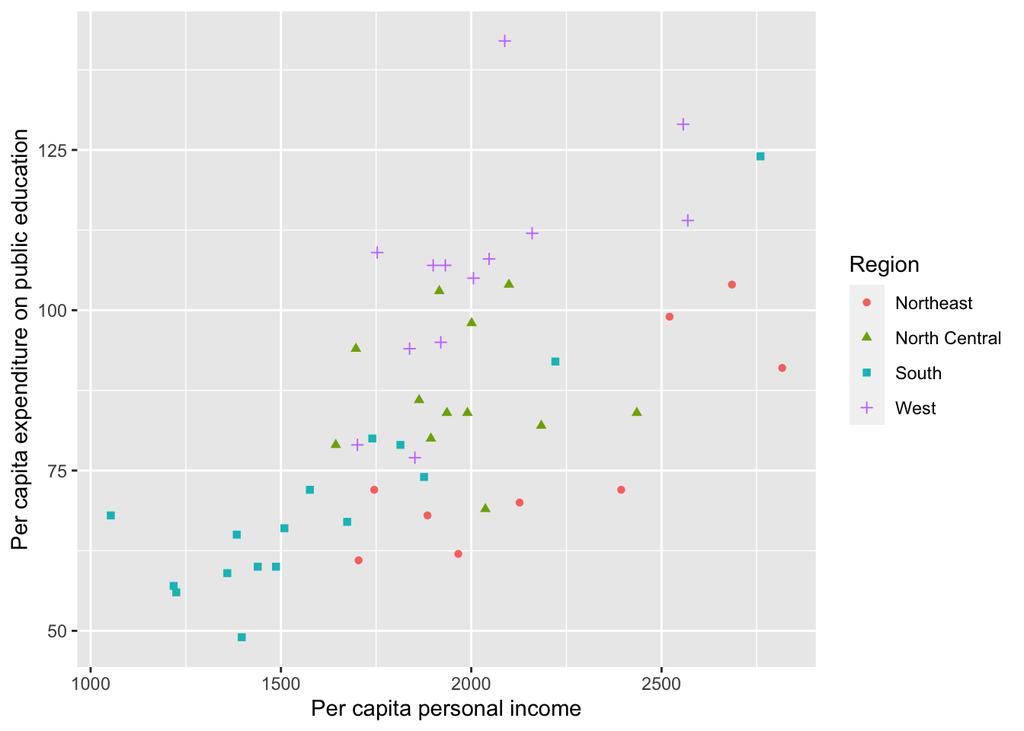

```r
correlation <- cor(expenditure$Y, expenditure$X1)

ggplot(expenditure) +
  geom_point(aes(x = X1, y = Y, color = Region, shape = Region)) +
  xlab("Per capita personal income") +
  ylab("Per capita expenditure on public education") +
  labs(color = "Region")
```

The correlation coefficient between Y and X1 is 0.6491296

Y and X1 seem to have a moderate (almost strong) positive correlation.